```python
%%shell
jupyter nbconvert --to html /content/Trab_2_de_IA.ipynb
```

```
[NbConvertApp] Converting notebook /content/Trab_2_de_IA.ipynb to html
[NbConvertApp] Writing 1897642 bytes to /content/Trab_2_de_IA.html
```

# Trabalho 2 - SCC0230 - Inteligência Artificial

Integrantes do grupo:

- Matheus Bermudes Viana - 11849797
- Rafael Kuhn Takano - 11200459
- Vinicius Silva Fernandes Kuhlmann - 11218772
- Vitor Souza Amim - 11218772

# Introdução aos algoritimos

- Árvore de decisão: Um algoritimo de aprendizado de máquina supervisionado que pode ser utilizado para classificação ou regressão. O algoritimo funciona com uma estrutura de dados composta por nós em uma hierarquia se iniciando com um nó raiz e precorrendo seus filhos de acordo com regras de if-else até a chegada a um nó folha como resposta.
- K-Nearest Neighbors (KNN): Um algoritimo de aprendizado de máquina superviosonado e não-parametrico (K é considerado um hiperparâmetro pois é selecionado manualmente e permanece fixo) baseado em distância. O algoritimo assume que dados de uma mesma categoria estão próximos um do outro, a escolha do hiperparametro K geralmente é feita com base em teste e erro sendo utilizado o melhor resultado do ambiente de teste porém não existe uma regra fixa para sua escolha.
- Naive Bayes: Esse algoritimo utiliza o teorema de Bayes como principío fundamental e utilizada para classificação de atributos discretos e utiliza uma abordagem "ingenua" por assumir que os atributos são não correlacionados entre si.Outra premissa que deve ser definida é a distribuição estátistica dos atributos, neste estudo utilizamos a gaussiana como parâmetro.
- Multilayer Perceptron (MLP): Um algoritimo de deep learning que utiliza de neural networks para realizar um aprendizado supervisionado dos dados. Seu funcionamento se baseia no uso de multiplos camadas perceptrons que recebem uma serie de inputs e realizam uma média ponderada que é ajustada na fase de testes e caso o seu threshold seja atingido o perceptron tem o output 1 caso contrário 0. Esse algoritimo possui no minimo 3 camadas, uma de input, uma ou mais intermediarias e uma de output.

```python
!pip install matplotlib==3.1.3 --upgrade
!pip install -U scikit-learn --user
import matplotlib.pyplot as plt
import matplotlib
import pandas as pd
import seaborn as sns
import numpy as np
```

```python
import math
import typing
from dataclasses import dataclass

from sklearn.model_selection import cross_validate
from sklearn.naive_bayes import GaussianNB
from sklearn.neighbors import KNeighborsClassifier
from sklearn.neural_network import MLPClassifier
from sklearn.tree import DecisionTreeClassifier


class ScikitModel(typing.Protocol):
    def fit(self, X, y, sample_weight=None): ...
    def predict(self, X): ...
    def score(self, X, y, sample_weight=None): ...
    def set_params(self, **params): ...


@dataclass
class ModelTest:
  name: str
  model: ScikitModel
  params: typing.List[typing.Dict[str, typing.Any]]

  def __post_init__(self):
    self.best_score = None

  def __str__(self):
    if self.best_score is None:
      raise AttributeError('best_score has not been defined yet, find_best_parameter() must be called')
    return f'{self.name} = {self.best_score.mean():.4f} +/- {self.best_score.std():.4f}'

  def find_best_parameter(self, X, y) -> None:
    """ Encontra o melhor score do tipo de modelo, testa todos os conjuntos de parâmetros """
    best_score = 0.0

    for p in self.params:
      self.model.set_params(**p) # Muda os parâmetros do modelo
      scores = cross_validate(self.model, X, y, cv=10, return_estimator=True)['test_score']
      if scores.mean() > best_score:
        best_score = scores

    self.best_score = best_score

MODELS = [
   ModelTest('KNN', KNeighborsClassifier(), [
     #{},
     #{'n_neighbors': 10},
     {'n_neighbors': 20},
   ]),
  ModelTest('Naive Bayes', GaussianNB(), [
    {}
  ]),
  ModelTest('Decision tree', DecisionTreeClassifier(), [
    {'random_state': 0},
    # {'max_depth': 3, 'random_state': 0},
    # {'max_depth': 5, 'random_state': 0},
    # {'max_depth': 10, 'random_state': 0}
  ]),
  ModelTest('MLP', MLPClassifier(), [
    {'max_iter': 2000}
  ])
]

def absolute_diff(score1, score2):
  """ Retorna True se score2 é melhor que score1, False caso contrário """
  mean1, mean2 = score1.mean(), score2.mean()
  std1, std2 = score1.std(), score2.std()
  diff = (mean1 - mean2) / math.sqrt( (std1**2 + std2**2) / 2 )
  return diff < 0

def find_best_model(X, y, model_tests: typing.List[ModelTest] = MODELS):
  """ Encontra o melhor modelo para um certo conjunto de dados """
  best_model, second_best_model = None, None

  for m in model_tests:
    m.find_best_parameter(X, y)
    print(str(m))

    # Verifica se o modelo é um dos dois melhores
    if best_model is None or absolute_diff(best_model.best_score, m.best_score):
      second_best_model = best_model
      best_model = m
    elif second_best_model is None or absolute_diff(second_best_model.best_score, m.best_score):
      second_best_model = m

  print(f'Best model: {str(best_model)}')
  print(f'Second best model: {str(second_best_model)}')
```

# Dataset 1: Classificação de Espécies de Lírios

São fornecidos os dados sobre 4 caracteristicas das flores de lírios e a classe equivalente à espécie do lírio em específico.

O data set consiste em 50 amostras de cada uma das três espécies de Lírio (Iris Setosa, Iris virginica, and Iris versicolor), totalizando 150 amostras. Além disso quatro atributos foram medidos de cada amostra:

- sepal_length: comprimento da sépala
- sepal_width: largura da sépala
- petal_length: comprimento da pétala
- petal_width: largura da sépala

## Tratamento

```python
# https://www.kaggle.com/datasets/arshid/iris-flower-dataset
iris = pd.read_csv('./IRIS.csv')
iris.head(10)
```

|  | sepal_length | sepal_width | petal_length | petal_width | species |
| --- | --- | --- | --- | --- | --- |
| 0 | 5.1 | 3.5 | 1.4 | 0.2 | Iris-setosa |
| 1 | 4.9 | 3.0 | 1.4 | 0.2 | Iris-setosa |
| 2 | 4.7 | 3.2 | 1.3 | 0.2 | Iris-setosa |
| 3 | 4.6 | 3.1 | 1.5 | 0.2 | Iris-setosa |
| 4 | 5.0 | 3.6 | 1.4 | 0.2 | Iris-setosa |
| 5 | 5.4 | 3.9 | 1.7 | 0.4 | Iris-setosa |
| 6 | 4.6 | 3.4 | 1.4 | 0.3 | Iris-setosa |
| 7 | 5.0 | 3.4 | 1.5 | 0.2 | Iris-setosa |
| 8 | 4.4 | 2.9 | 1.4 | 0.2 | Iris-setosa |
| 9 | 4.9 | 3.1 | 1.5 | 0.1 | Iris-setosa |

```python
iris.info()
```

```
<class 'pandas.core.frame.DataFrame'>
RangeIndex: 150 entries, 0 to 149
Data columns (total 5 columns):
 #   Column        Non-Null Count  Dtype
---  ------        --------------  -----
 0   sepal_length  150 non-null    float64
 1   sepal_width   150 non-null    float64
 2   petal_length  150 non-null    float64
 3   petal_width   150 non-null    float64
 4   species       150 non-null    object
dtypes: float64(4), object(1)
memory usage: 6.0+ KB
```

```python
iris.describe()
```

|  | sepal_length | sepal_width | petal_length | petal_width |
| --- | --- | --- | --- | --- |
| count | 150.000000 | 150.000000 | 150.000000 | 150.000000 |
| mean | 5.843333 | 3.054000 | 3.758667 | 1.198667 |
| std | 0.828066 | 0.433594 | 1.764420 | 0.763161 |
| min | 4.300000 | 2.000000 | 1.000000 | 0.100000 |
| 25% | 5.100000 | 2.800000 | 1.600000 | 0.300000 |
| 50% | 5.800000 | 3.000000 | 4.350000 | 1.300000 |
| 75% | 6.400000 | 3.300000 | 5.100000 | 1.800000 |
| max | 7.900000 | 4.400000 | 6.900000 | 2.500000 |

```python
iris.columns
```

```
Index(['sepal_length', 'sepal_width', 'petal_length', 'petal_width',
       'species'],
      dtype='object')
```

```python
iris.shape
```

```
(150, 5)
```

```python
# Não há dados nulos nesse dataset, logo não é necessário o tratamento desse aspecto
iris.isnull().sum()
```

```
sepal_length    0
sepal_width     0
petal_length    0
petal_width     0
species         0
dtype: int64
```

```python
iris.species.value_counts()
```

```
Iris-setosa        50
Iris-versicolor    50
Iris-virginica     50
Name: species, dtype: int64
```

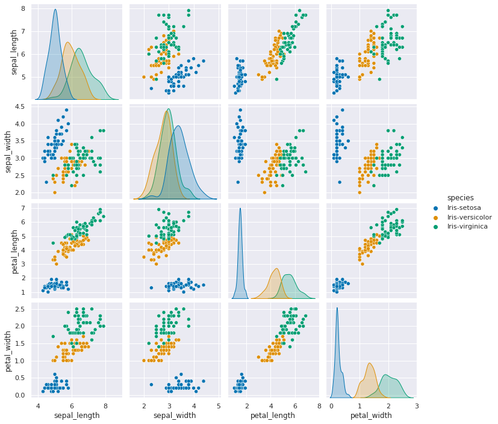

```python
# Plot de um correlograma para visualização dos dados
sns.set(context='notebook', style='darkgrid', palette='colorblind', font='sans-serif', font_scale=1, rc=None)
matplotlib.rcParams['figure.figsize'] =[8,8]
matplotlib.rcParams.update({'font.size': 15})
matplotlib.rcParams['font.family'] = 'sans-serif'
sns.set_style('darkgrid')
sns.pairplot(iris , hue='species')
```

```python
# Separa os atributos dos testes, e verifica
iris_x = iris.drop('species', axis=1)
iris_y = iris.species
print(iris_x.shape)
print(iris_y.shape)
```

```
(150, 4)
(150,)
```

## Modelagem

```python
# Verifica o melhor modelo para esse dataset
find_best_model(iris_x,iris_y)
```

```
KNN = 0.9800 +/- 0.0306
Naive Bayes = 0.9533 +/- 0.0427
Decision tree = 0.9600 +/- 0.0442
MLP = 0.9733 +/- 0.0533
Best model: KNN = 0.9800 +/- 0.0306
Second best model: MLP = 0.9733 +/- 0.0533
```

# Dataset 2: Classificação de Sobreviventes do Naufrágio do Titanic

Colunas:

- PassengerId: ID do passageiro
- Survived: Classe indicando a sobrevivência da amostra
- Pclass: Nivel da qualidade da passagem do passageiro (1 classe, 2 classe, 3 classe)
- Name: Nome do passageiro
- Sex: Gênero do passageiro
- Age: Idade do passageiro
- SibSp: Quantidade de irmãos e esposas que embarcaram junto
- Parch: Quantidade de Pais e filhos que embarcaram junto
- Ticket: numero da passagem
- Fare: Tarifa paga
- Cabin: ID da Cabine
- Embarked: Porto no qual embarcou

## Tratamento

```python
# https://www.kaggle.com/code/nadintamer/titanic-survival-predictions-beginner
titanic = pd.read_csv("train.csv")
titanic.describe(include="all")
```

|  | PassengerId | Survived | Pclass | Name | Sex | Age | SibSp | Parch | Ticket | Fare | Cabin | Embarked |
| --- | --- | --- | --- | --- | --- | --- | --- | --- | --- | --- | --- | --- |
| count | 891.000000 | 891.000000 | 891.000000 | 891 | 891 | 714.000000 | 891.000000 | 891.000000 | 891 | 891.000000 | 204 | 889 |
| unique | NaN | NaN | NaN | 891 | 2 | NaN | NaN | NaN | 681 | NaN | 147 | 3 |
| top | NaN | NaN | NaN | Braund, Mr. Owen Harris | male | NaN | NaN | NaN | 347082 | NaN | B96 B98 | S |
| freq | NaN | NaN | NaN | 1 | 577 | NaN | NaN | NaN | 7 | NaN | 4 | 644 |
| mean | 446.000000 | 0.383838 | 2.308642 | NaN | NaN | 29.699118 | 0.523008 | 0.381594 | NaN | 32.204208 | NaN | NaN |
| std | 257.353842 | 0.486592 | 0.836071 | NaN | NaN | 14.526497 | 1.102743 | 0.806057 | NaN | 49.693429 | NaN | NaN |
| min | 1.000000 | 0.000000 | 1.000000 | NaN | NaN | 0.420000 | 0.000000 | 0.000000 | NaN | 0.000000 | NaN | NaN |
| 25% | 223.500000 | 0.000000 | 2.000000 | NaN | NaN | 20.125000 | 0.000000 | 0.000000 | NaN | 7.910400 | NaN | NaN |
| 50% | 446.000000 | 0.000000 | 3.000000 | NaN | NaN | 28.000000 | 0.000000 | 0.000000 | NaN | 14.454200 | NaN | NaN |
| 75% | 668.500000 | 1.000000 | 3.000000 | NaN | NaN | 38.000000 | 1.000000 | 0.000000 | NaN | 31.000000 | NaN | NaN |
| max | 891.000000 | 1.000000 | 3.000000 | NaN | NaN | 80.000000 | 8.000000 | 6.000000 | NaN | 512.329200 | NaN | NaN |

```python
print(titanic.columns)
```

```
Index(['PassengerId', 'Survived', 'Pclass', 'Name', 'Sex', 'Age', 'SibSp',
       'Parch', 'Ticket', 'Fare', 'Cabin', 'Embarked'],
      dtype='object')
```

```python
print(pd.isnull(titanic).sum())
```

```
PassengerId      0
Survived         0
Pclass           0
Name             0
Sex              0
Age            177
SibSp            0
Parch            0
Ticket           0
Fare             0
Cabin          687
Embarked         2
dtype: int64
```

```python
# Remove atributos não significantes
titanic = titanic.drop(['Cabin'], axis = 1)
titanic = titanic.drop(['Ticket'], axis = 1)
```

```python
# Checa a moda
print("Number of people embarking in Southampton (S):")
southampton = titanic[titanic["Embarked"] == "S"].shape[0]
print(southampton)

print("Number of people embarking in Cherbourg (C):")
cherbourg = titanic[titanic["Embarked"] == "C"].shape[0]
print(cherbourg)

print("Number of people embarking in Queenstown (Q):")
queenstown = titanic[titanic["Embarked"] == "Q"].shape[0]
print(queenstown)
```

```
Number of people embarking in Southampton (S):
644
Number of people embarking in Cherbourg (C):
168
Number of people embarking in Queenstown (Q):
77
```

```python
# Troca os valores invalidos pela moda
titanic = titanic.fillna({"Embarked": "S"})
```

```python
#Diminui a quantidade de valores para idade por meio de faixas de idade
titanic["Age"] = titanic["Age"].fillna(-0.5)
bins = [-1, 0, 5, 12, 18, 24, 35, 60, np.inf]
labels = ['Unknown', 'Baby', 'Child', 'Teenager', 'Student', 'Young Adult', 'Adult', 'Senior']
titanic['AgeGroup'] = pd.cut(titanic["Age"], bins, labels = labels)
```

```python
# Define o atributo titulo e vê os mais comuns
combine = [titanic]

for dataset in combine:
    dataset['Title'] = dataset.Name.str.extract(' ([A-Za-z]+)\.', expand=False)

pd.crosstab(titanic['Title'], titanic['Sex'])
```

| Sex Title | female | male |
| --- | --- | --- |
| Capt | 0 | 1 |
| Col | 0 | 2 |
| Countess | 1 | 0 |
| Don | 0 | 1 |
| Dr | 1 | 6 |
| Jonkheer | 0 | 1 |
| Lady | 1 | 0 |
| Major | 0 | 2 |
| Master | 0 | 40 |
| Miss | 182 | 0 |
| Mlle | 2 | 0 |
| Mme | 1 | 0 |
| Mr | 0 | 517 |
| Mrs | 125 | 0 |
| Ms | 1 | 0 |
| Rev | 0 | 6 |
| Sir | 0 | 1 |

```python
# Diminui a quantidade de titulos para simplificar a classificação
for dataset in combine:
    dataset['Title'] = dataset['Title'].replace(['Lady', 'Capt', 'Col',
    'Don', 'Dr', 'Major', 'Rev', 'Jonkheer', 'Dona'], 'Rare')

    dataset['Title'] = dataset['Title'].replace(['Countess', 'Lady', 'Sir'], 'Royal')
    dataset['Title'] = dataset['Title'].replace('Mlle', 'Miss')
    dataset['Title'] = dataset['Title'].replace('Ms', 'Miss')
    dataset['Title'] = dataset['Title'].replace('Mme', 'Mrs')

titanic[['Title', 'Survived']].groupby(['Title'], as_index=False).mean()
```

|  | Title | Survived |
| --- | --- | --- |
| 0 | Master | 0.575000 |
| 1 | Miss | 0.702703 |
| 2 | Mr | 0.156673 |
| 3 | Mrs | 0.793651 |
| 4 | Rare | 0.285714 |
| 5 | Royal | 1.000000 |

```python
# Mapeia cada titulo a um valor numerico
title_mapping = {"Mr": 1, "Miss": 2, "Mrs": 3, "Master": 4, "Royal": 5, "Rare": 6}
for dataset in combine:
    dataset['Title'] = dataset['Title'].map(title_mapping)
    dataset['Title'] = dataset['Title'].fillna(0)

titanic.head()
```

|  | PassengerId | Survived | Pclass | Name | Sex | Age | SibSp | Parch | Fare | Embarked | Title |
| --- | --- | --- | --- | --- | --- | --- | --- | --- | --- | --- | --- |
| 0 | 1 | 0 | 3 | Braund, Mr. Owen Harris | male | 22.0 | 1 | 0 | 7.2500 | S | 1 |
| 1 | 2 | 1 | 1 | Cumings, Mrs. John Bradley (Florence Briggs Th... | female | 38.0 | 1 | 0 | 71.2833 | C | 3 |
| 2 | 3 | 1 | 3 | Heikkinen, Miss. Laina | female | 26.0 | 0 | 0 | 7.9250 | S | 2 |
| 3 | 4 | 1 | 1 | Futrelle, Mrs. Jacques Heath (Lily May Peel) | female | 35.0 | 1 | 0 | 53.1000 | S | 3 |
| 4 | 5 | 0 | 3 | Allen, Mr. William Henry | male | 35.0 | 0 | 0 | 8.0500 | S | 1 |

```python
# Preenche idades vazias de acordo com a moda do mesmo titulo
mr_age = titanic[titanic["Title"] == 1]["AgeGroup"].mode() #Young Adult
miss_age = titanic[titanic["Title"] == 2]["AgeGroup"].mode() #Student
mrs_age = titanic[titanic["Title"] == 3]["AgeGroup"].mode() #Adult
master_age = titanic[titanic["Title"] == 4]["AgeGroup"].mode() #Baby
royal_age = titanic[titanic["Title"] == 5]["AgeGroup"].mode() #Adult
rare_age = titanic[titanic["Title"] == 6]["AgeGroup"].mode() #Adult

age_title_mapping = {1: "Young Adult", 2: "Student", 3: "Adult", 4: "Baby", 5: "Adult", 6: "Adult"}

for x in range(len(titanic["AgeGroup"])):
    if titanic["AgeGroup"][x] == "Unknown":
        titanic["AgeGroup"][x] = age_title_mapping[titanic["Title"][x]]

# Transforma as faixas de idades em valores
age_mapping = {'Baby': 1, 'Child': 2, 'Teenager': 3, 'Student': 4, 'Young Adult': 5, 'Adult': 6, 'Senior': 7}
titanic['AgeGroup'] = titanic['AgeGroup'].map(age_mapping)


titanic = titanic.drop(['Age'], axis = 1)
```

```python
# Remove o nome pois ja foi utilizada a informação dos titulos
titanic = titanic.drop(['Name'], axis = 1)
```

```python
# Mapeia o sexo a valores numericos
sex_mapping = {"male": 0, "female": 1}
titanic['Sex'] = titanic['Sex'].map(sex_mapping)
```

```python
#Mapeia o embarque a valores numericos
embarked_mapping = {"S": 1, "C": 2, "Q": 3}
titanic['Embarked'] = titanic['Embarked'].map(embarked_mapping)
```

```python
# Mapeia as faixas de tarifa em quatro possiveis valores
titanic['FareBand'] = pd.qcut(titanic['Fare'], 4, labels = [1, 2, 3, 4])

# Remove as tarifas
titanic = titanic.drop(['Fare'], axis = 1)
```

```python
# Separa a variável resposta
titanic_x = titanic.drop(['Survived', 'PassengerId'], axis=1)
titanic_y = titanic["Survived"]
```

## Modelagem

```python
# Redefine MODELS para alterar um parametro de MLP
MODELS = [
   ModelTest('KNN', KNeighborsClassifier(), [
     #{},
     #{'n_neighbors': 10},
     {'n_neighbors': 20},
   ]),
  ModelTest('Naive Bayes', GaussianNB(), [
    {}
  ]),
  ModelTest('Decision tree', DecisionTreeClassifier(), [
    {'random_state': 0},
    # {'max_depth': 3, 'random_state': 0},
    # {'max_depth': 5, 'random_state': 0},
    # {'max_depth': 10, 'random_state': 0}
  ]),
  ModelTest('MLP', MLPClassifier(), [
    {},
  ])
]
```

```python
find_best_model(titanic_x,titanic_y)
```

```
KNN = 0.7722 +/- 0.0334
Naive Bayes = 0.7879 +/- 0.0271
Decision tree = 0.7779 +/- 0.0496
MLP = 0.7969 +/- 0.0416
Best model: MLP = 0.7969 +/- 0.0416
Second best model: Naive Bayes = 0.7879 +/- 0.0271
```

# Dataset 3: Classificação de Casos de doenças Cardiovasculares

O Dataset contém 918 amostras com 11 atributos e a classe booleana indicando se foi uma doença cardiovascular ou não.

Os atributos do dataset são os seguintes:

- Age: idade
- Gender: Gênero sexual
- Different types of Chest Pain: Tipo de dor no peito
- Resting Blood Pressure: Pressão arterial em repouso
- Cholesterol Level: Valor do colesterol no sange
- Fasing BS level: Valor de glicemia no sangue
- Resting ECG: Resultado do exame de Eletrocardiograma
- Maximum value of HR: Valor máximo da taxa de batimentos cardiácos
- Exercise Angina: Valor boleano indicando se a pessoal é sedentária ou não (N: é sedentaria, Y: pratica atividades físicas)
- Oldpeak: Amplitude da baixa na batida do coração
- ST slop value: tipo de "slop" amostrado no segmento ST do batimento cardíaco

**HeartDisease** é a classe do dataset, indicando se é caso de doença cardiaaca.

## Tratamento

```python
# https://www.kaggle.com/datasets/fedesoriano/heart-failure-prediction
heart = pd.read_csv('./heart.csv')
heart
```

|  | Age | Sex | ChestPainType | RestingBP | Cholesterol | FastingBS | RestingECG | MaxHR | ExerciseAngina | Oldpeak | ST_Slope | HeartDisease |
| --- | --- | --- | --- | --- | --- | --- | --- | --- | --- | --- | --- | --- |
| 0 | 40 | M | ATA | 140 | 289 | 0 | Normal | 172 | N | 0.0 | Up | 0 |
| 1 | 49 | F | NAP | 160 | 180 | 0 | Normal | 156 | N | 1.0 | Flat | 1 |
| 2 | 37 | M | ATA | 130 | 283 | 0 | ST | 98 | N | 0.0 | Up | 0 |
| 3 | 48 | F | ASY | 138 | 214 | 0 | Normal | 108 | Y | 1.5 | Flat | 1 |
| 4 | 54 | M | NAP | 150 | 195 | 0 | Normal | 122 | N | 0.0 | Up | 0 |
| ... | ... | ... | ... | ... | ... | ... | ... | ... | ... | ... | ... | ... |
| 913 | 45 | M | TA | 110 | 264 | 0 | Normal | 132 | N | 1.2 | Flat | 1 |
| 914 | 68 | M | ASY | 144 | 193 | 1 | Normal | 141 | N | 3.4 | Flat | 1 |
| 915 | 57 | M | ASY | 130 | 131 | 0 | Normal | 115 | Y | 1.2 | Flat | 1 |
| 916 | 57 | F | ATA | 130 | 236 | 0 | LVH | 174 | N | 0.0 | Flat | 1 |
| 917 | 38 | M | NAP | 138 | 175 | 0 | Normal | 173 | N | 0.0 | Up | 0 |

918 rows × 12 columns

```python
heart.info()
```

```
<class 'pandas.core.frame.DataFrame'>
RangeIndex: 918 entries, 0 to 917
Data columns (total 12 columns):
 #   Column          Non-Null Count  Dtype
---  ------          --------------  -----
 0   Age             918 non-null    int64
 1   Sex             918 non-null    object
 2   ChestPainType   918 non-null    object
 3   RestingBP       918 non-null    int64
 4   Cholesterol     918 non-null    int64
 5   FastingBS       918 non-null    int64
 6   RestingECG      918 non-null    object
 7   MaxHR           918 non-null    int64
 8   ExerciseAngina  918 non-null    object
 9   Oldpeak         918 non-null    float64
 10  ST_Slope        918 non-null    object
 11  HeartDisease    918 non-null    int64
dtypes: float64(1), int64(6), object(5)
memory usage: 86.2+ KB
```

```python
data1 = heart['HeartDisease'].value_counts()
print(data1)
```

```
1    508
0    410
Name: HeartDisease, dtype: int64
```

```python
heart.isna().sum().sum()
```

```
0
```

```python
heart.isnull().sum().sum()
```

```
0
```

### Tratamento de Valores Nulos e não numéricos

As seguintes features serão transformadas em valores númericos:

- Sex
- ChestPainType
- RestingECG
- ExerciseAngina
- ST_Slope

```python
from sklearn.preprocessing import LabelEncoder

le = LabelEncoder()
heart.Sex = le.fit_transform(heart.Sex)

le = LabelEncoder()
heart.ChestPainType = le.fit_transform(heart.ChestPainType)

le = LabelEncoder()
heart.RestingECG = le.fit_transform(heart.RestingECG)

le = LabelEncoder()
heart.ExerciseAngina = le.fit_transform(heart.ExerciseAngina)

le = LabelEncoder()
heart.ST_Slope = le.fit_transform(heart.ST_Slope)
```

```python
# Separa a variável resposta
heart_X = heart.drop('HeartDisease', axis=1)
heart_y = heart['HeartDisease']
```

## Modelagem

```python
find_best_model(heart_X, heart_y)
```

```
KNN = 0.7003 +/- 0.0955
Naive Bayes = 0.8452 +/- 0.0591
Decision tree = 0.7809 +/- 0.0502
MLP = 0.7995 +/- 0.0507
Best model: Naive Bayes = 0.8452 +/- 0.0591
Second best model: MLP = 0.7995 +/- 0.0507
```

# Dataset 4: Classificação de estudades com Ansiedade e Depressão

O Dataset contém 6982 amostras com 2 atributos, o texto de um estudante e a classe booleana indicando se o aluno possui ansiedade e/ou depressão ou não.

## Tratamento

```python
# https://www.kaggle.com/code/sasakitetsuya/students-anxiety-and-depression-classify-model/
anxiety = pd.read_excel('./dataset.xlsx')
anxiety.head()
```

|  | text | label |
| --- | --- | --- |
| 0 | oh my gosh | 1.0 |
| 1 | trouble sleeping, confused mind, restless hear... | 1.0 |
| 2 | All wrong, back off dear, forward doubt. Stay ... | 1.0 |
| 3 | I've shifted my focus to something else but I'... | 1.0 |
| 4 | I'm restless and restless, it's been a month n... | 1.0 |

```python
print(anxiety.shape)
```

```
(6982, 2)
```

### Tratamento de valores nulos

```python
anxiety.isnull().sum()
```

```
text     10
label     2
dtype: int64
```

```python
anxiety=anxiety.dropna(how='any')
```

```python
anxiety['label'].value_counts()
```

```
0.0    6240
1.0     730
Name: label, dtype: int64
```

[figure not shown]

```python
labels = [0,1]
sizes = [6240, 730]
custom_colours = ['#ff7675', '#74b9ff']

plt.figure(figsize=(20, 6), dpi=227)
plt.subplot(1, 2, 1)
plt.pie(sizes, labels = labels, textprops={'fontsize': 15}, startangle=140,
       autopct='%1.0f%%', colors=custom_colours, explode=[0, 0.05])

plt.subplot(1, 2, 2)
sns.barplot(x = anxiety['label'].unique(), y = anxiety['label'].value_counts(), palette= 'viridis')

plt.show()
```

### Organizando as features do dataset

```python
# Adição do atributo total de palavras na frase do 'text'
anxiety['Total Words'] = anxiety['text'].apply(lambda x: len(x.split()))

def count_total_words(text):
    char = 0
    for word in text.split():
        char += len(word)
    return char

anxiety['Total Chars'] = anxiety["text"].apply(count_total_words)
```

```python
anxiety.head()
```

|  | text | label | Total Words | Total Chars |
| --- | --- | --- | --- | --- |
| 0 | oh my gosh | 1.0 | 3 | 8 |
| 1 | trouble sleeping, confused mind, restless hear... | 1.0 | 10 | 55 |
| 2 | All wrong, back off dear, forward doubt. Stay ... | 1.0 | 14 | 65 |
| 3 | I've shifted my focus to something else but I'... | 1.0 | 11 | 51 |
| 4 | I'm restless and restless, it's been a month n... | 1.0 | 14 | 59 |

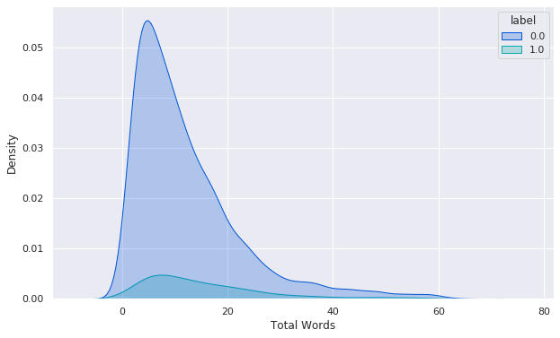

```python
# Plota distribuição das amostras na quantidade de palavras
plt.figure(figsize = (10, 6))
sns.kdeplot(x = anxiety['Total Words'], hue= anxiety['label'], palette= 'winter', shade = True)
plt.show()
```

### Pré-processamento dos textos

```python
anxiety.head()
```

|  | text | label | Total Words | Total Chars |
| --- | --- | --- | --- | --- |
| 0 | oh my gosh | 1.0 | 3 | 8 |
| 1 | trouble sleeping, confused mind, restless hear... | 1.0 | 10 | 55 |
| 2 | All wrong, back off dear, forward doubt. Stay ... | 1.0 | 14 | 65 |
| 3 | I've shifted my focus to something else but I'... | 1.0 | 11 | 51 |
| 4 | I'm restless and restless, it's been a month n... | 1.0 | 14 | 59 |

```python
def converter_minusculo(text):
    text = text.lower()
    return text

anxiety['text'] = anxiety['text'].apply(converter_minusculo)
```

```python
import re
def remove_url(text):
    re_url = re.compile('https?://\S+|www\.\S+')
    return re_url.sub('', text)

anxiety['text'] = anxiety['text'].apply(remove_url)
```

```python
import string
exclude = string.punctuation

def remover_pontuacao(text):
    return text.translate(str.maketrans('', '', exclude))

anxiety['text'] = anxiety['text'].apply(remover_pontuacao)
```

```python
import nltk
nltk.download('punkt')
nltk.download('stopwords')
from wordcloud import WordCloud
from nltk import sent_tokenize, word_tokenize
from nltk.corpus import stopwords
from nltk.stem import PorterStemmer

def remover_palavras_insignificantes(text):
    new_list = []
    words = word_tokenize(text)
    stopwrds = stopwords.words('english')
    for word in words:
        if word not in stopwrds:
            new_list.append(word)
    return ' '.join(new_list)

anxiety['text'] = anxiety['text'].apply(remover_palavras_insignificantes)
```

```python
def padronizacao_palavras(text):
    stemmer = PorterStemmer()
    new_list = []
    words = nltk.word_tokenize(text)
    for word in words:
        new_list.append(stemmer.stem(word))

    return " ".join(new_list)

anxiety['text'] = anxiety['text'].apply(padronizacao_palavras)
```

```python
# adiciona um atributo da quantidade de palavras no texto após a transformação
anxiety['Total Words After Transformation'] = anxiety['text'].apply(lambda x: np.log(len(x.split())))
```

```python
anxiety.head()
```

|  | text | label | Total Words | Total Chars | Total Words After Transformation |
| --- | --- | --- | --- | --- | --- |
| 0 | oh gosh | 1.0 | 3 | 8 | 0.693147 |
| 1 | troubl sleep confus mind restless heart tune | 1.0 | 10 | 55 | 1.945910 |
| 2 | wrong back dear forward doubt stay restless re... | 1.0 | 14 | 65 | 2.197225 |
| 3 | ive shift focu someth els im still worri | 1.0 | 11 | 51 | 2.079442 |
| 4 | im restless restless month boy mean | 1.0 | 14 | 59 | 1.791759 |

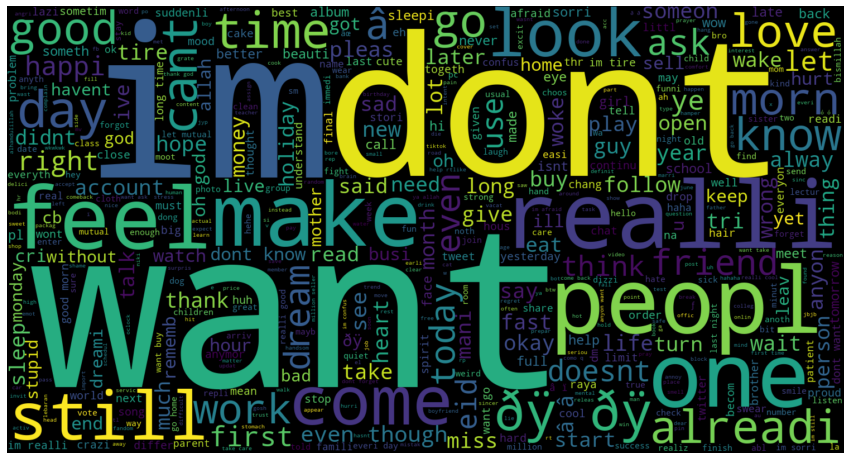

```python
# Faz uma wordcloud das palavras mais comuns em pessoas sem depressão/ansiedade
text = " ".join(anxiety[anxiety['label'] == 0]['text'])
plt.figure(figsize = (15, 10))
wordcloud = WordCloud(max_words=500, height= 800, width = 1500,  background_color="black", colormap= 'viridis').generate(text)
plt.imshow(wordcloud, interpolation="bilinear")
plt.axis('off')
plt.show()
```

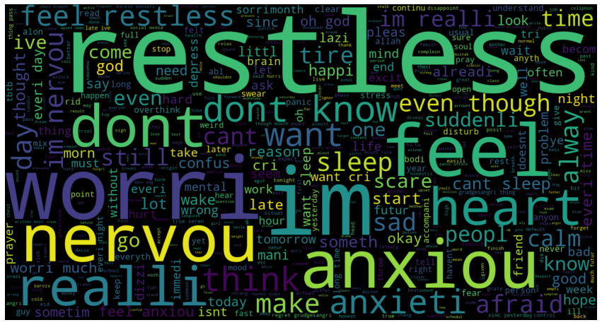

```python
# Faz uma wordcloud das palavras mais comuns em pessoas com depressão/ansiedade
text = " ".join(anxiety[anxiety['label'] == 1]['text'])
plt.figure(figsize = (15, 10))
wordcloud = WordCloud(max_words=500, height= 800, width = 1500,  background_color="black", colormap= 'viridis').generate(text)
plt.imshow(wordcloud, interpolation="bilinear")
plt.axis('off')
plt.show()
```

```python
# Aplica o tfidf nos textos para utilizar como atributos do classificador

from sklearn.feature_extraction.text import TfidfVectorizer

anxiety_X = anxiety["text"]
anxiety_y = anxiety['label'].values

tfidf = TfidfVectorizer(max_features= 2500, min_df= 2)
anxiety_X = tfidf.fit_transform(anxiety_X).toarray()
```

## Modelagem

```python
# Redefine MODELS para alterar um parametro de MLP
MODELS = [
   ModelTest('KNN', KNeighborsClassifier(), [
     #{},
     #{'n_neighbors': 10},
     {'n_neighbors': 20},
   ]),
  ModelTest('Naive Bayes', GaussianNB(), [
    {}
  ]),
  ModelTest('Decision tree', DecisionTreeClassifier(), [
    {'random_state': 0},
    # {'max_depth': 3, 'random_state': 0},
    # {'max_depth': 5, 'random_state': 0},
    # {'max_depth': 10, 'random_state': 0}
  ]),
  ModelTest('MLP', MLPClassifier(), [
    {'max_iter': 4},
  ])
]
```

```python
find_best_model(anxiety_X,anxiety_y)
```

```
KNN = 0.9106 +/- 0.0034
Naive Bayes = 0.6953 +/- 0.0165
Decision tree = 0.9868 +/- 0.0062
MLP = 0.9703 +/- 0.0064
Best model: Decision tree = 0.9868 +/- 0.0062
Second best model: MLP = 0.9703 +/- 0.0064
```

# Conclusão

O resultado das previsões de todos os algoritimos foram muito bem no primeiro data set de classficação de Lirios e possuiram pouca variação entre si ainda que não houvessem tantos dados para teste isso pode ser explicado pela pouca quantidade de atributos e pelo fato de ser um data set cujo sabemos a priori a relevancia de cada atributo (O problema de classificação de Lirios é bem conhecido e esses são os atributos utilizados), não houve um algoritimo com uma acuracia abaixo de 95%, sendo o melhor algoritimo o de KNN com 98% e MLP com 97.3%, o pior deles foi o de Naive Bayes com 95%.

Para o terceiro data set referente ao diagnostico de doença cardiaca, a performance média também foi menos satifatória perto dos 80% mas houve maior variabilidade entre os algoritimos. O pior algoritimo , KNN, obteve uma acurácia notávelmente inferior de 70% seguido pelo decision tree com 78%, MLP com 80% e naive bayes com um desempenho claramente superior de 84.5%. O bom desempenho do Naive Bayes provavelmente se deve ao fato de que sua premissa de não dependencia entre atributos provavelmente estava correta com atributos independentes possuindo um bom valor de predição por si só. A baixa performance do KNN pode ser explicada também por sua premissa, desta vez não tão boa,como os atributos provavelmente são independentes a distância entre os dados perde relevância.

O ultimo data set foi o mais complexo e envolveu técnicas como TF-IDF para predição usando textos sobre o diagnóstico de depressão e ansiedade. KNN, Decision Tree e MLP foram todos acima de 90% de acurácia sendo os melhores Decision Tree e MLP com 98.6% e 97% respectivamente. O algoritimo de Naive bayes foi extremamente pior em relação aos demais com apenas 69% de acurácia, isso implica uma grande correlação entre as palavras usadas como atributos, o que era de se esperar dado que o contexto pode alterar completamente o sentido de uma dada palavra.

É possível concluir dos experimentos que dado a identificação correta da premissa dos dados é possível realizar uma decisão informada sobre o melhor algoritimo para se utilizar, entretanto para problemas em que essa questão não é óbvia um algóritimo mais genérico e confiavel é a melhor opção, entre os 4 testados neste estudo essa opção seria o algoritimo de MLP.